# Capital, Labour and Justice

Lecture 2: Discrimination

Dr David Chivers

Political Economy

## The Effects of Discrimination

- Lost Einsteins: If women, minorities and children from low-income families were to invent at the same rate as white men from high-income families, the rate of innovation in the United States would quadruple.
- Hsieh et al. (2013) - in 1960, 94% of doctors and lawyers were white men. In 2008, this figure reduced to 62%.
- Between 1960 to 2008: 15-20% of growth in aggregate output per worker is explained by the improved allocation of talent.
- These negative effects of discrimination on productivity is called **misallocation**

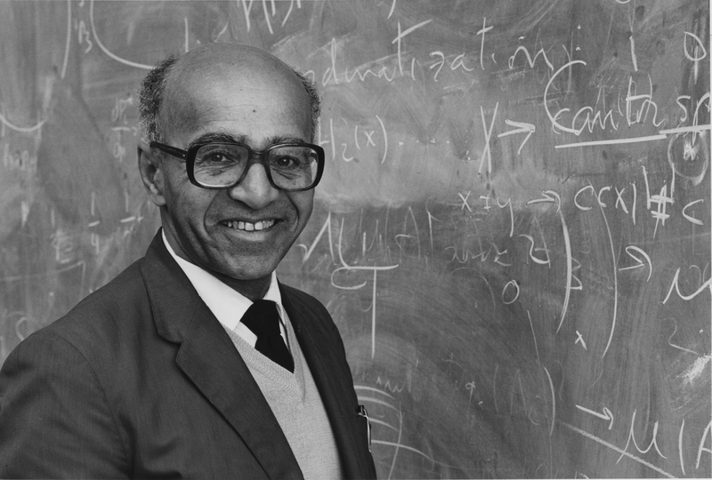

David Blackwell. Despite getting his Ph.D. at age 22 he was not permitted to attend lectures at Princeton and was denied employment at U.C. Berkeley for racial reasons.

## What types of discrimination are there?

## Discrimination Types

- **Type 1:** **Discrimination by relevant characteristics** e.g. qualifications.
  - Disparities in outcomes are driven by disparities in observable characteristics
- **Type 2: Statistical discrimination:** sorting based on group averages on relevant characteristics
  - When an observable characteristic might be used as a proxy for unobservable characteristic if statistically correlated
- **Type 3: “Preference-based” discrimination**:
  - When decision-makers care about an observable characteristic in and of itself.

## Discrimination Types

- **Another Type: Systematic Discrimination**?
- Economists, for the most part, do not cover this type of discrimination, unlike sociologists (Reskin 2012)
- For example, If certain groups are more likely to have been in prison, employers may statistically discriminate in employment.
- If then discrimination in the legal systems makes this group more likely to be in prison, then it affects employment.
- If then poor employment prospects make crime more attractive, then the legal system may statistically discriminate and so on…
- Economists would usually call this general equilibrium effects, which are hard to disentangle empirically.

## Statistical Discrimination

- Bayesians (all of us?) use conditional probability to form judgements $P(A\mid B)$.
- For example, we typically only screen women for breast cancer even though some men get breast cancer
- If e.g. gender or race is correlated with unobserved (or imperfectly observed) outcomes like productivity or crime, firms who wish to maximise profits will statistically discriminate
- Note: this relationship does not have to be causal
  $$P(\text{Crime}\mid\text{Group 1})<P(\text{Crime}\mid\text{Group 2}).$$
- However, perceived correlations can often be inaccurate and self-reenforcing
- Even if these correlations were accurate, it may still have negative effects on individuals and society

## Discrimination - Evidence

### Markets

- Buyers were less likely to make an offer for iPod Nanos (ancient listening device) from Black sellers and make lower offers if they did (Doleac and Stein 2013).
- Arab buyers and sellers also face discrimination in online market for used cars in Israel (Zussman 2013).

### Employment

- 9.7% of C.V.s with a white-sounding name elicited a callback, relative to 6.5% black-sounding names (Bertrand and Mullainathan, 2004)
- However, could also be linked to social class as there is considerable variation in callback rates across names within race (Jacquemet and Yannelis, 2012)

## Models of Discrimination

## Becker’s Neoclassical Model

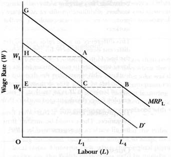

## Becker’s Neoclassical Model

- Two groups: both groups are equally productive
- Discrimination gives rise to two separate demand curve

### Biased Firms

- Employ workers from the high-wage group at $L_{1}$ with wage $W_{1}$ and face lower profits ($AGH$)
- Or employ workers from the disadvantaged group at $L_{1}$ with wage $W_{4}$ and increase profits ($ACEH$)
- Discrimination imposes a cost on the firm as well as the disadvantaged group via lower employment/wages.

## Becker’s Model - Criticism

- The threat of future statistical discrimination can lead to lower levels of investment in human capital which would ultimately decrease wages.
- If biased employers exist, and job search is costly, then black job-seekers will have lower reservation wages. This leads them to accept lower offers. Unbiased employers will therefore offer black job candidates lower wages as well (Lang and Lehmann, 2012)
- As small amounts of bias can lead to segregation, and this leads to insular social networks. This slows the rate at which employers update inaccurate group stereotypes (see Arrow, 1998).
- Cognitive biases mean humans recall e.g. population distributions, in a way that exaggerates true differences across groups (Bordalo et al., 2016)

## Modelling Discrimination

- In the US, Black workers face shorter employment spells than non-black workers (Bowlus & Eckstein, 2002)
- Young Black male high school graduates had 2/3rds the job spell duration of their White counterparts.

### Monitoring decisions hurt black workers (Cavounidis et al., 2024):

- If firms scrutinise Black workers more closely, a larger share of low-productivity workers will become unemployed
- As a result, the Black unemployed pool gets “churned” and will be weaker on average than the White unemployment pool
- Employers, statistically discriminate and use race as an indicator of expected productivity
- This makes monitoring Black workers “optimal” for firms, and discrimination becomes a self-fulling prophecy.
- Black workers that “pass” scrutiny become good matches for firms
- The gap between Black and White workers employment spells narrows with seniority

## Modelling Discrimination

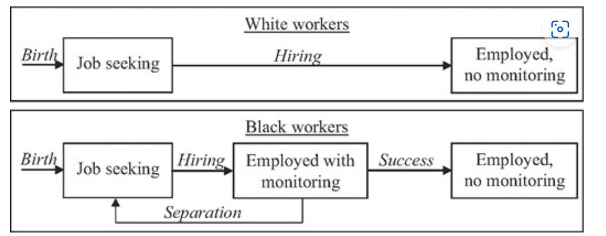

## Segregation

- A small amount of bias can result in large levels of segregation
- Let’s say you have a small preference to be around others like yourself e.g.
- “I want to move if less than 1/3 of my neighbours are like me.”
- To find out what happens, we can play [Parable of the Polygons](https://tinyco.re/4763470).
- Schelling (1971) proved this in his paper: Dynamic Models of Segregation.

[figure not shown]

## Interventions

## Interventions

### Ban the Box (BTB)

- In the US, BTB stop employers from asking a job applicant about their criminal record until late in the hiring process.
- The reason: applicants with criminal records are less likely to get callbacks from employers, holding all other things constant.
- Research shows BTB does not help people with criminal records get jobs (Rose, 2017).
- When employers cannot ask about criminal records, they increase racial statistical discrimination. As a result, employment of young, low-skilled, black men fell (Doleac and Hansen, 2018).
- Sowell (2022) argues this shows interventions do not work and may even make things worse.
- However, Doleac (2020) argues some interventions do work if they are carefully designed.
- For example, Court-issued rehabilitation certificates work to increase callbacks for job and housing applicants (Leasure and Martin, 2017).

## Positive Action

### Positive Action

- Positive action is a set of policies that seek to benefit groups that have been historically discriminated against and are unrepresented in e.g. education and employment
- In the UK positive discrimination is illegal under the Equality Act 2010. However, positive action is not
- For example, if the candidates are of equal merit, membership of a particular disadvantaged group can become a “tie breaker”
- In the US this is known as “affirmative action”. The phrase originates from JFK’s executive order in 1961: “take affirmative action to ensure that applicants are employed, and employees are treated [fairly] during employment, without regard to their race, creed, color, or national origin“
- In the US, affirmative action is a controversial topic: the Supreme Court in 2023 explicitly rejected affirmative action regarding race in college admissions

## Positive Action

- **Affirmative action** has successfully increased black employment (Kurtulus, 2016)
- Effects seem to persist even have polices end as employers increase investment in recruiting and screening (Miller, 2017)
- **Workplace mentoring** having more minority employees in senior positions increases type-based mentoring and enables increased promotion of future minority candidates
- This can lead to minority groups to investing in human capital as potential benefits have increased (Moro, 2011)
- **“Best person for the job”:** affirmative action does not seem to cause productivity loss by not hiring (Holzer and Neumark, 2000)
- This could be that quotas increases number and quality of applicants who apply (Niederle, Segal and Vesterlund, 2013).

## Quotas

### Sweden

- Social Democratic party centrally adopted a gender quota. On average, a 10% point increase in female representation raised the proportion of competent men by 3% points.
- Conclusion: mediocre men have an incentive to surround themselves with mediocre men (Besley et al., 2017)
- Gender quotas expand perception of women being qualified for leadership (OBrien and Rickne, 2016)

### India

- A random subset of Indian villages to elect women reduced male voters negative views about women’s leadership (Beaman et al., 2009).
- Hypothesized mechanism: quotas allowed men to experience female leadership and reducing statistical discrimination.
- Changes in attitude and information led to more women being elected later when quotas ended (Beaman et al., 2009)
- Women Role models: increased girls career aspirations and educational attainment (Beaman et al., 2012)

## Discrimination

### Beauty

- Below-average looking people earn less than average-looking people, who earn less than good-looking people (Hamermesh and Biddle, 1994)
- The “plainness” penalty is 5-10%, slightly larger than the “beauty” premium.

### Height

- Taller people have higher incomes, better education outcomes and report being happier (Deaton and Arora, 2009)

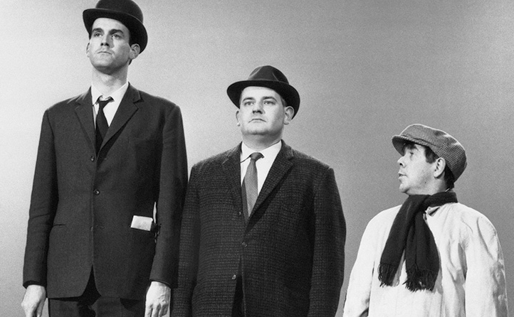

## Summary

- Discrimination leads to misallocation
- There are 3(4?) types of discrimination and widespread evidence for their existence
- The Neoclassical model (Becker) is useful as a starting point but has many drawbacks
- Interventions can work but they have to be carefully designed
- See [Talis](https://durham.rl.talis.com/modules/econ2301.html) for **reading list**.

Note: not all citations in this lecture are listed there.